# Lista de Exercícios III

Visualização de dados: Uma abordagem baseada no {ggplot2}

Guilherme Cadori

02/04/2023

### Preparação

Vamos iniciar esse estudo carregando a bibliteca de trabalho. Nesse exercício usaremos a biblioteca *tidyverse* que traz consigo outras bibliotecas que serão úteis para nossa análise, além da biblioteca *ggplot2*, que será utilizada para plotar os gráficos.

```r
# Carregando a biblioteca de trabalho
library(tidyverse)
# Configurando o diretório de trabalho, importando dados e atribuindo os mesmos à variável 'dados3'

setwd("C:/Guilherme/MSc/Disciplinas/2023-03 MÉTODOS COMPUTACIONAIS EM ESTATÍSTICA E OTIMIZAÇÃO/Aula 3")

dados3 <- read.csv2("Dados_Estatisticos.csv", skip = 1)

# Conferindo os dados importados

head(dados3)
```

```
##   EMPRESA_SIGLA                    EMPRESA_NOME EMPRESA_NACIONALIDADE  ANO MES
## 1               ABAET\xc9 LINHAS A\xc9REAS LTDA            BRASILEIRA 2000   5
## 2               ABAET\xc9 LINHAS A\xc9REAS LTDA            BRASILEIRA 2000   5
## 3               ABAET\xc9 LINHAS A\xc9REAS LTDA            BRASILEIRA 2000  11
## 4               ABAET\xc9 LINHAS A\xc9REAS LTDA            BRASILEIRA 2000  11
## 5               ABAET\xc9 LINHAS A\xc9REAS LTDA            BRASILEIRA 2000  11
## 6           AAL         AMERICAN AIRLINES, INC.           ESTRANGEIRA 2000   1
##   AEROPORTO_DE_ORIGEM_SIGLA   AEROPORTO_DE_ORIGEM_NOME AEROPORTO_DE_ORIGEM_UF
## 1                      SBLP          BOM JESUS DA LAPA                     BA
## 2                      SNGI                   GUANAMBI                     BA
## 3                      SBAR                    ARACAJU                     SE
## 4                      SBSV                   SALVADOR                     BA
## 5                      SNBR                  BARREIRAS                     BA
## 6                      KDFW DALLAS & FORT WORTH, TEXAS
##   AEROPORTO_DE_ORIGEM_REGIAO     AEROPORTO_DE_ORIGEM_PAIS
```

[output cut: 55 more lines]

```r
str(dados3)
```

```
## 'data.frame':    962762 obs. of  38 variables:
##  $ EMPRESA_SIGLA                  : chr  "" "" "" "" ...
##  $ EMPRESA_NOME                   : chr  "ABAET\xc9 LINHAS A\xc9REAS LTDA" "ABAET\xc9 LINHAS A\xc9REAS LTDA" "ABAET\xc9 LINHAS A\xc9REAS LTDA" "ABAET\xc9 LINHAS A\xc9REAS LTDA" ...
##  $ EMPRESA_NACIONALIDADE          : chr  "BRASILEIRA" "BRASILEIRA" "BRASILEIRA" "BRASILEIRA" ...
##  $ ANO                            : int  2000 2000 2000 2000 2000 2000 2000 2000 2000 2000 ...
##  $ MES                            : int  5 5 11 11 11 1 1 1 1 1 ...
##  $ AEROPORTO_DE_ORIGEM_SIGLA      : chr  "SBLP" "SNGI" "SBAR" "SBSV" ...
##  $ AEROPORTO_DE_ORIGEM_NOME       : chr  "BOM JESUS DA LAPA" "GUANAMBI" "ARACAJU" "SALVADOR" ...
##  $ AEROPORTO_DE_ORIGEM_UF         : chr  "BA" "BA" "SE" "BA" ...
##  $ AEROPORTO_DE_ORIGEM_REGIAO     : chr  "NORDESTE" "NORDESTE" "NORDESTE" "NORDESTE" ...
##  $ AEROPORTO_DE_ORIGEM_PAIS       : chr  "BRASIL" "BRASIL" "BRASIL" "BRASIL" ...
##  $ AEROPORTO_DE_ORIGEM_CONTINENTE : chr  "AM\xc9RICA DO SUL" "AM\xc9RICA DO SUL" "AM\xc9RICA DO SUL" "AM\xc9RICA DO SUL" ...
##  $ AEROPORTO_DE_DESTINO_SIGLA     : chr  "SNGI" "SBSV" "SBSV" "SBPL" ...
##  $ AEROPORTO_DE_DESTINO_NOME      : chr  "GUANAMBI" "SALVADOR" "SALVADOR" "PETROLINA" ...
##  $ AEROPORTO_DE_DESTINO_UF        : chr  "BA" "BA" "BA" "PE" ...
```

[output cut: 24 more lines]

### Questão 1)

Considere que é de interesse visualizar a série temporal (anual) do número de decolagens para as 10 empresas nacionais que mais decolaram no período disponível de dados. Faça duas visualizações uma para enfatizar a comparação entre as empresas e outra para enfatizar a visualização da série de cada empresa. Considere apenas os registros que tenham o número de decolagens.

```r
# Agrupando dados: 10 empresas nacionais que mais decolaram durante todo o período, DESCONSIDERANDO NAs

# Criando subset das empresas de interesse
dadosSub_Q1 <- subset(dados3, EMPRESA_NACIONALIDADE == "BRASILEIRA" & EMPRESA_SIGLA != "")

dadosSub_Q1Viz <- dadosSub_Q1 %>%
                    group_by(EMPRESA_SIGLA) %>%
                    summarise(DecolagensTotal = sum(DECOLAGENS, na.rm = TRUE)) %>%
                    arrange(desc(DecolagensTotal)) %>%
                    top_n(DecolagensTotal, n=10)

# Criando um vetor para extrair apenas as empreasas de interesse da base de dados
dadosSub_Q1Vec <- c(dadosSub_Q1Viz$EMPRESA_SIGLA)

# Utilizando o vetor para criar um subset com empresas-alvo e anos do período de avaliação
dadosSub_Q1_vecSec <- subset(dados3, EMPRESA_SIGLA %in% dadosSub_Q1Vec)

# Agrupando dados por ano e por empresa e oerdenando por ano
dadosSub_vecSecViz <- dadosSub_Q1_vecSec %>%
                        group_by(ANO, EMPRESA_SIGLA) %>%
                        summarize(DecolagensTotal = sum(DECOLAGENS, na.rm = TRUE)) %>%
                        arrange(ANO) %>%
                        top_n(10)
```

[output not shown]

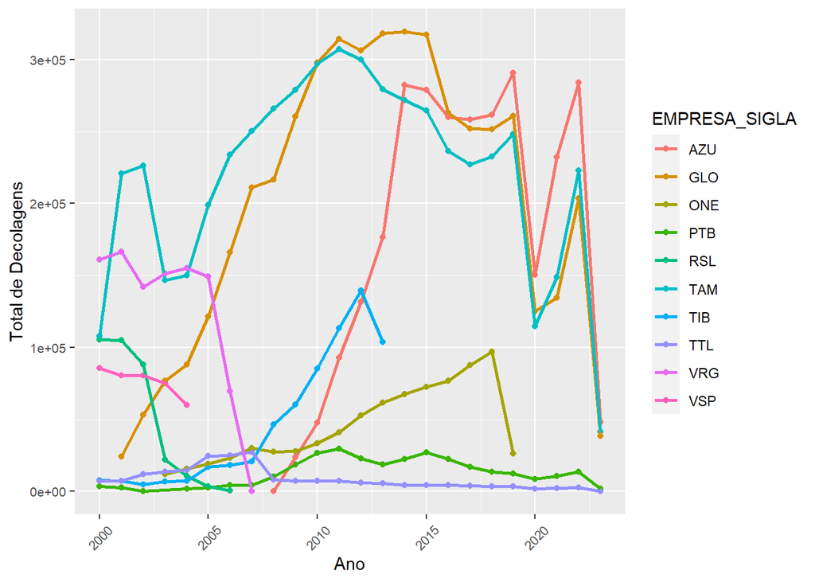

```r
# Plotando gráfico 1:
# Série temporal comparando a quantidade de decolagens para as 10 empresas que mais decolaram no período
ggplot(data = dadosSub_vecSecViz,
       mapping = aes(x = ANO,
                     y = DecolagensTotal,
                     color = EMPRESA_SIGLA)) +
       labs(x = "Ano",
            y = "Total de Decolagens") +
  geom_point() +
  geom_line(linewidth = 1) +
  theme(axis.text.x=element_text(size = 8,
                                 angle = 45,
                                 vjust = 0.5),
        axis.text.y=element_text(size = 8))
```

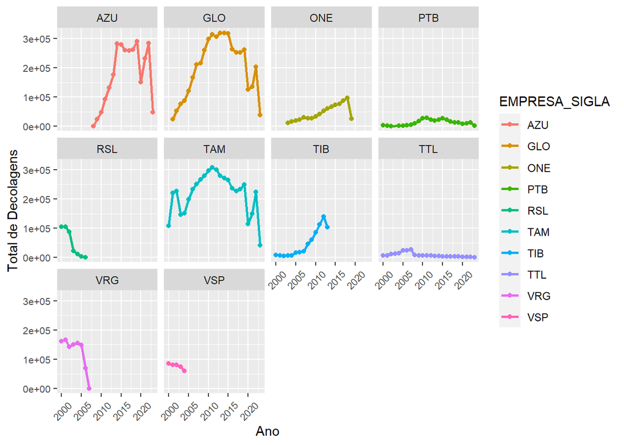

```r
# Plotando gráfico 2:
# Série temporal individualizada para cada empresa
ggplot(dadosSub_vecSecViz,
       mapping = aes(x = ANO,
                     y = DecolagensTotal,
                     color = EMPRESA_SIGLA)) +
       labs(x = "Ano",
            y = "Total de Decolagens") +
  geom_point() +
  geom_line(linewidth = 1) +
  facet_wrap(~ EMPRESA_SIGLA) +
  theme(axis.text.x=element_text(size = 8,
                                 angle = 45,
                                 vjust = 0.5),
        axis.text.y=element_text(size = 8))
```

### Questão 2)

Faça uma visualização de dados comparar o número de passageiros pagantes entre empresas nacionais e estrangeiras ao longo dos anos.

```r
# Criando subset para criação dos gráficos
dadosSub_Q2 <- subset(dados3, EMPRESA_SIGLA != "")

# Agrupando dados de passageiros pagantes por nacionalidade da compania aérea por ano
dadosSub_Q2Viz <- dadosSub_Q2 %>%
  group_by(ANO, EMPRESA_NACIONALIDADE) %>%
  summarise(PassageirosPagantesTotal = sum(PASSAGEIROS_PAGOS, na.rm = TRUE)) %>%
  arrange(ANO)
```

[output not shown]

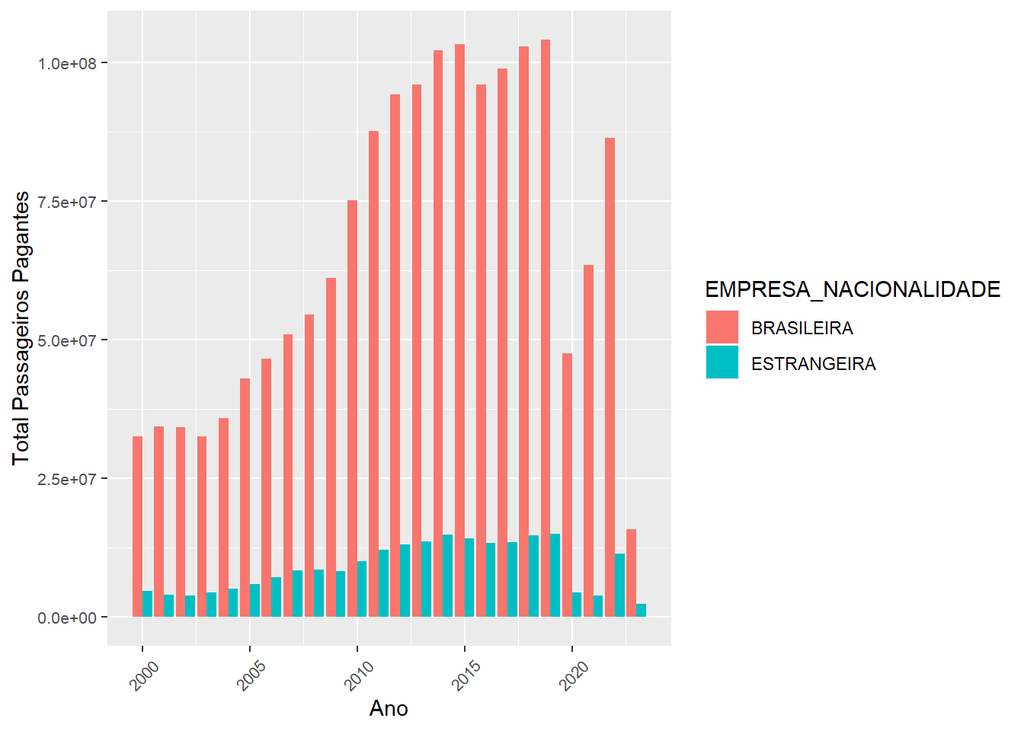

```r
# Plotando gráfico de passageiros pagantes por nacionalidade da compania aérea ao longo do tempo
ggplot(data = dadosSub_Q2Viz,
       mapping = aes(x = ANO,
                     y = PassageirosPagantesTotal,
                     fill = EMPRESA_NACIONALIDADE)) +
  labs(x = "Ano",
       y = "Total Passageiros Pagantes") +
  geom_col(position = "dodge") +
  theme(axis.text.x=element_text(size = 8,
                                 angle = 45,
                                 vjust = 0.5),
        axis.text.y=element_text(size = 8))
```

### Questão 3)

Faça uma visualização de dados comparar o número de passageiros pagantes entre empresas nacionais e estrangeiras de acordo com o grupo de voo.

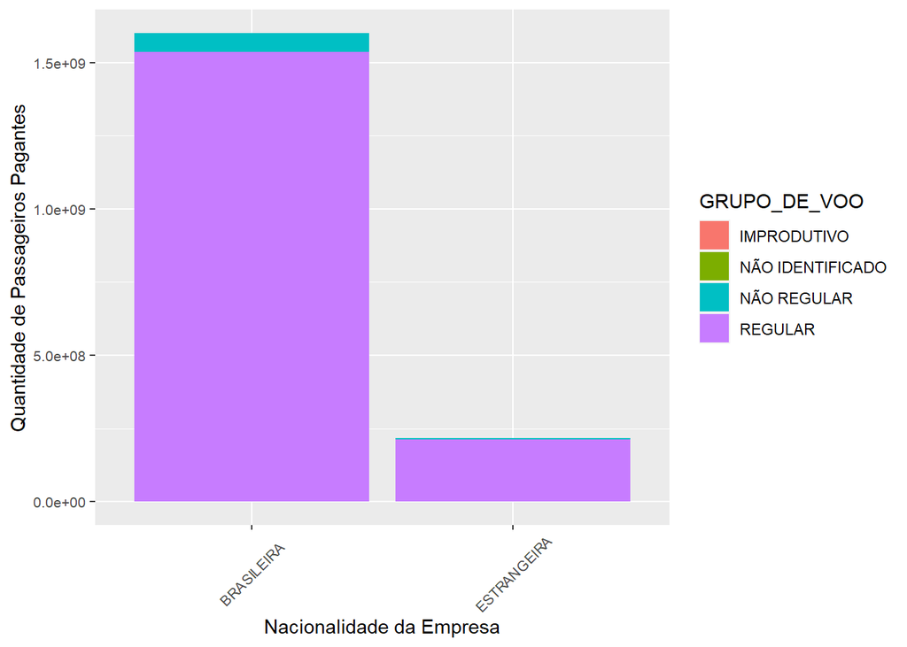

```r
# Criando subset de dados para manipulação
dados3_fix <- subset(dados3, GRUPO_DE_VOO != "" & EMPRESA_SIGLA != "")

# Ajustando valores na variável "GRUPO_DE_VOO"
dados3_fix$GRUPO_DE_VOO <- ifelse(dados3_fix$GRUPO_DE_VOO == "N\xc3O REGULAR", "NÃO REGULAR",
                           ifelse(dados3_fix$GRUPO_DE_VOO == "N\xc3O IDENTIFICADO", "NÃO IDENTIFICADO",
                                 dados3_fix$GRUPO_DE_VOO))

# Agrupando a quantidade de passageiros pagantes por empresas nacionais e internacionais
# de acordo com seu grupo de voo
dados3_fix_Viz <- dados3_fix %>%
  group_by(EMPRESA_NACIONALIDADE, GRUPO_DE_VOO) %>%
  summarise(QtPassageirosPagantes = sum(PASSAGEIROS_PAGOS, na.rm = TRUE))
# Plotando gráfico
ggplot(data = dados3_fix_Viz,
       mapping = aes(x = EMPRESA_NACIONALIDADE,
                     y = QtPassageirosPagantes,
                     fill = GRUPO_DE_VOO)) +
  geom_col(position = "stack") +
  labs(x = "Nacionalidade da Empresa",
       y = "Quantidade de Passageiros Pagantes") +
  theme(axis.text.x=element_text(size = 8,
                                 angle = 45,
                                 vjust = 0.5),
        axis.text.y=element_text(size = 8))
```

### Questão 4)

Faça uma visualização para enfatizar a distribuição da variável número de passageiros pagantes de acordo com a região de origem e natureza do voo. Enfatize a comparação entre DOMÉSTICA e INTERNACIONAL para cada região de origem. Para criar o gráfico use o log10 da variável PASSAGEIROS_PAGOS.

```r
# Craindo subset de dados
dadosSub_Q4 <- dados3_fix

# Ajustando valores da variável NATUREZA
dadosSub_Q4$NATUREZA<- ifelse(dadosSub_Q4$NATUREZA == "DOM\xc9STICA", "DOMÉSTICA", dadosSub_Q4$NATUREZA)

# Agrupando a quantidade de passageiros pagantes por região de origem e para empresas domésticas e internacionais
# de acordo com a natureza do vôo
dados4_Viz <- dadosSub_Q4 %>%
  group_by(AEROPORTO_DE_ORIGEM_REGIAO, NATUREZA, EMPRESA_NACIONALIDADE) %>%
  summarise(QtPassageirosPagantes = sum(PASSAGEIROS_PAGOS, na.rm = TRUE))
```

```
## You can override using the `.groups` argument.
```

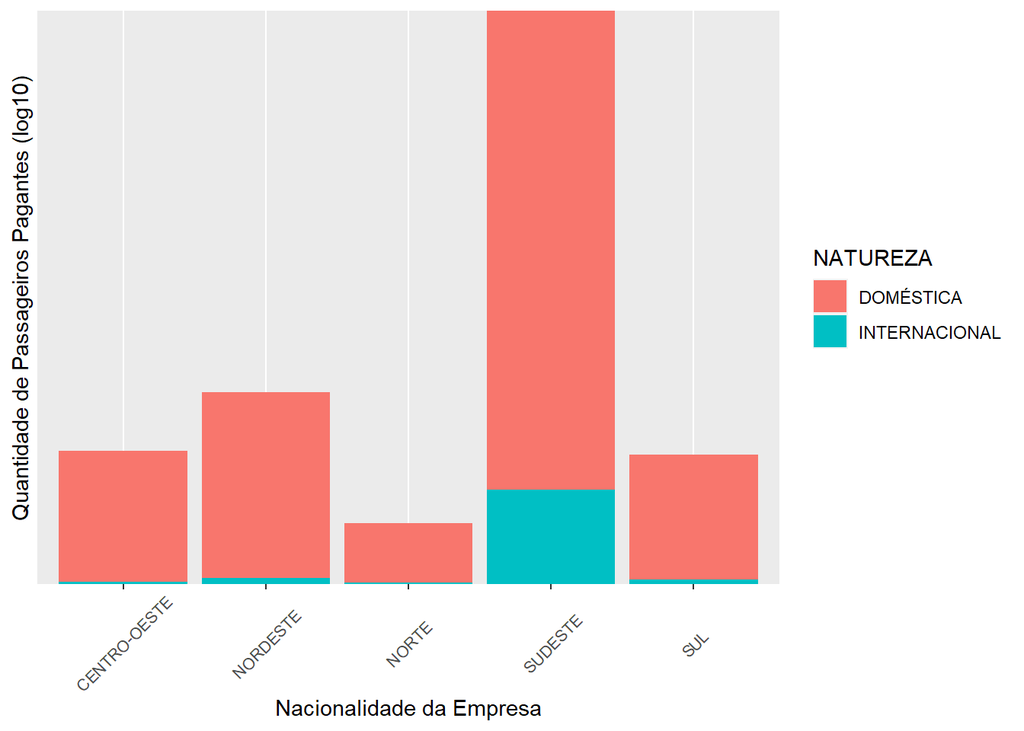

```r
## Removendo valores faltantes em AEROPORTO_DE_ORIGEM_REGIAO
dados4_VizFix <- subset(dados4_Viz, AEROPORTO_DE_ORIGEM_REGIAO != "" & AEROPORTO_DE_ORIGEM_REGIAO != " ")

# Plotando gráfico para o agrupamento realizado
ggplot(data = dados4_VizFix,
       mapping = aes(x = AEROPORTO_DE_ORIGEM_REGIAO,
                     y = QtPassageirosPagantes,
                     fill = NATUREZA)) +
  labs(x = "Nacionalidade da Empresa",
       y = "Quantidade de Passageiros Pagantes (log10)") +
  theme(axis.text.x=element_text(size = 8,
                                 angle = 45,
                                 vjust = 0.5),
        axis.text.y=element_text(size = 8, angle = 90, hjust = 1)) +
  scale_y_log10() +
  geom_col(position = "stack") +
  scale_y_discrete(labels = function(x) str_wrap(x, width = 0))
```

### Questão 5)

Crie uma variável que indique a eficiencia no uso do combustível como sendo a razão entre o DISTANCIA_VOADA_KM e COMBUSTIVEL_LITROS. Compare as empresas de acordo com a região de origem e destino. Use a escala y em log10 para facilitar a comparação das regiões.

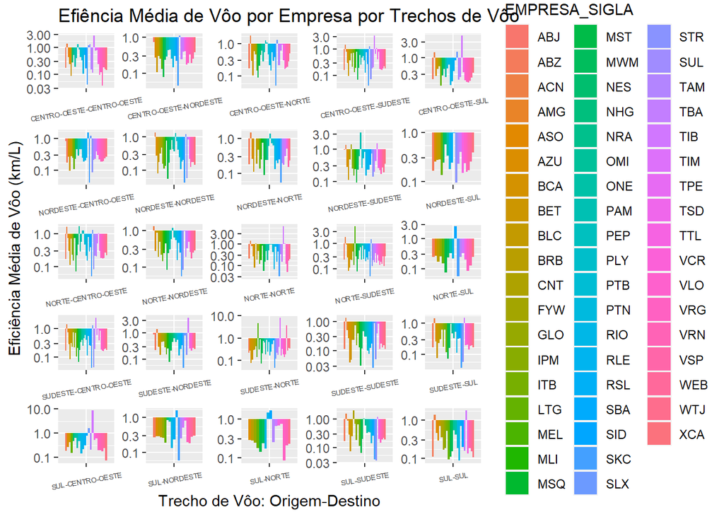

```r
# Craindo subset de trabalho
dadosSub_Q5 <- dadosSub_Q4
dadosSub_Q5 <- subset(dadosSub_Q5,
                      AEROPORTO_DE_ORIGEM_SIGLA != "" &
                      AEROPORTO_DE_ORIGEM_REGIAO != "" &
                      AEROPORTO_DE_ORIGEM_REGIAO != " " &
                      AEROPORTO_DE_DESTINO_REGIAO != "" &
                      AEROPORTO_DE_DESTINO_REGIAO != " " &
                      !is.na(DISTANCIA_VOADA_KM) &
                      !is.na(COMBUSTIVEL_LITROS))

# Criando variável de eficiência de vôo (km/L) e adicionado à base de dados
dadosSub_Q5$EficienciaVoo <- dadosSub_Q5$DISTANCIA_VOADA_KM / dadosSub_Q5$COMBUSTIVEL_LITROS

# Removendo registror com valores nulos
dadosSub_Q5_fix <- subset(dadosSub_Q5, EficienciaVoo != "")

# Criando variável combinando região de origem e reigão de destino para agrupamento das empresas
dadosSub_Q5_fix$Combincao_OrigDest <- paste(dadosSub_Q5_fix$AEROPORTO_DE_ORIGEM_REGIAO,
                                            dadosSub_Q5_fix$AEROPORTO_DE_DESTINO_REGIAO,
                                            sep = "-")

# Agrupando empresas por grupo ORIGEM-DESTINO e calculando a média da efiência de cada empresa dentro do mesmo grupo
dadosSub_Q5_Viz <- dadosSub_Q5_fix %>%
  group_by(Combincao_OrigDest, EMPRESA_SIGLA) %>%
  summarise(EficienciaMediaVoo = mean(EficienciaVoo, na.rm = TRUE))
# Limpando valores de média com problemas
dadosSub_Q5_VizFix <- subset(dadosSub_Q5_Viz,
                             EficienciaMediaVoo != Inf &
                             !is.nan(EficienciaMediaVoo) &
                             EficienciaMediaVoo != 0)

# Plotando gráfico de eficiência de voo das empresas agrupadas por região de origem e destino
# e utilizando o eixo y (eficiência de voo) na escala log10 para facilitar a comparação das regiões
ggplot(data = dadosSub_Q5_VizFix,
       mapping = aes(x = Combincao_OrigDest,
                     y = EficienciaMediaVoo,
                     fill = EMPRESA_SIGLA)) +
  labs(x = "Trecho de Vôo: Origem-Destino", y = "Eficiência Média de Vôo (km/L)",
       title = "Efiência Média de Vôo por Empresa por Trechos de Vôo") +
  theme(axis.text.x=element_text(size = 5,
                                 angle = 10,
                                 vjust = 0.5)) +
  scale_y_log10() +
  geom_col(position = "dodge") +
  facet_wrap(~ Combincao_OrigDest, scales = "free") +
  theme(strip.text.x = element_blank())
```

### Questão 6)

Faça uma visualização para mostrar a relação entre o consumo de combustível e a distância voada. Considere empresas nacionais e internacionais e os diferentes anos para enriquecer a visualização. Considere transformar as variáveis e use alguma forma estatística para enfatizar a forma do relacionamento.

```r
# Criando subset de dados
dadossub_q6 <- dados3 %>%
  filter() %>%
  drop_na(COMBUSTIVEL_LITROS) %>%
  drop_na(DISTANCIA_VOADA_KM) %>%
  group_by(ANO, EMPRESA_NACIONALIDADE, EMPRESA_NOME) %>%
  summarise(total_comb = sum(COMBUSTIVEL_LITROS), total_dist = sum(DISTANCIA_VOADA_KM)) %>%
  mutate(consumo = total_dist/total_comb) %>%
  arrange(consumo) %>%
  head(10)
```

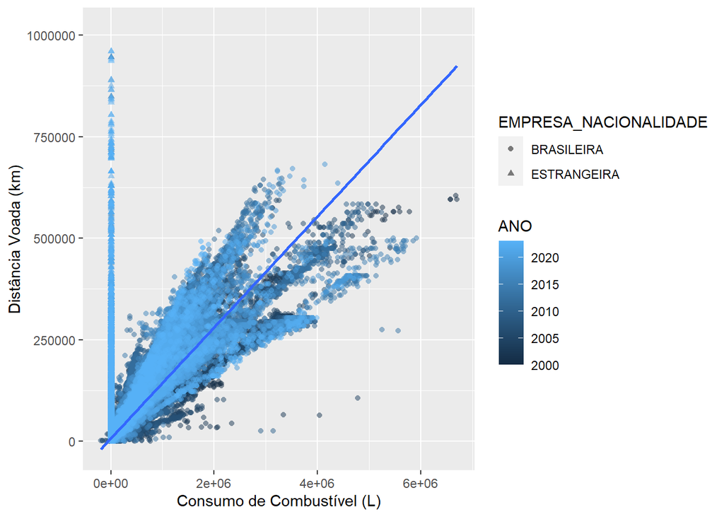

```r
# Criando variável de consumo médio de combustível
dadossub_q6New <- transform(dados3,DISTANCIA_VOADA_KM = as.integer(DISTANCIA_VOADA_KM))

dadossub_q6New["Média de Consumo"] <- dados3$COMBUSTIVEL_LITROS / dados3$DISTANCIA_VOADA_KM

ggplot(data = dadossub_q6New,
       mapping = aes(x = COMBUSTIVEL_LITROS,
                     y = DISTANCIA_VOADA_KM,
                     color = ANO,
                     shape = EMPRESA_NACIONALIDADE)) +
  labs(x = "Consumo de Combustível (L)",
       y = "Distância Voada (km)") +
  geom_point(alpha = 0.5) +
  geom_smooth(method = "lm")
```

### Questão 7)

Baseado na visualização em 6 você diria que tem alguma incosistencia com esses dados? Justique.

### Resposta:

Há sim incosistência com os dados. Tal fato fica evidentemente claro quando observamos os registros plotados ao longo do eixo de Distância Voada (eixo y). Esse comportamento indica a possibilidade de os dados de Consumo de Combustível (eixo x) terem sido registrados na unidade errada ou até mesmo não terem sido registrados. Além disso, a presença de outliers na porção inferior do gráfico pode indicar a falha no registro da distância voada ou do consumo de combustível, umas vez que tais observações fogem do padrão esperando de comportamento.

### Questão 8)

Considerando apenas as empresas nacionais. Faça uma visualização para investigar se a região do aeroporto de origem influencia na relação entre combustível e distancia voada.

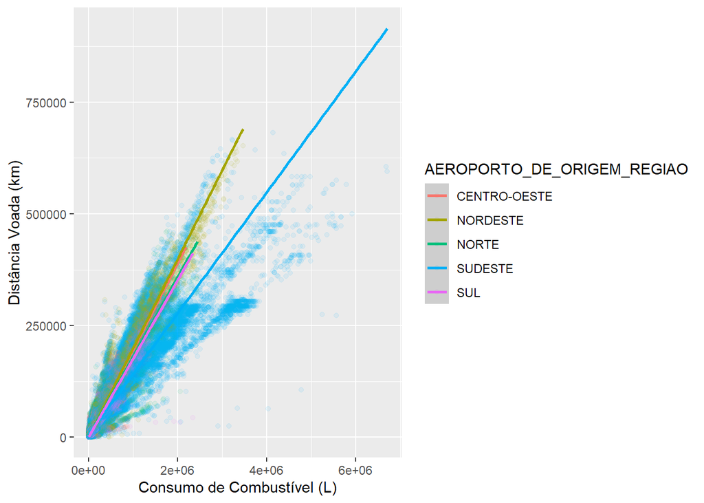

```r
subsSet_Q8 <-  dados3 %>%
  filter(EMPRESA_NACIONALIDADE == "BRASILEIRA", COMBUSTIVEL_LITROS > 0,
         DISTANCIA_VOADA_KM>0,AEROPORTO_DE_ORIGEM_REGIAO!= "")

ggplot(data = subsSet_Q8,
       mapping = aes(x = COMBUSTIVEL_LITROS,
                     y = DISTANCIA_VOADA_KM,
                     color = AEROPORTO_DE_ORIGEM_REGIAO)) +
  labs(x = "Consumo de Combustível (L)",
       y = "Distância Voada (km)") +
  geom_point(alpha = 0.08) +
  geom_smooth(method = "lm")
```

### Questão 9)

O indicador RTK (Revenue tonne kilometer) refere-se ao volume de toneladas quilômetros transportada. Faça uma visualização da relação deste indicador com o consumo de combustível. Filtre apenas observações com ambas variáveis maiores que zero. Considere também que é de interesse comparar essa relação entre os diferentes anos. Considere incluir alguma camada estatística para enfatizar o formato do relacionamento entre as variáveis.

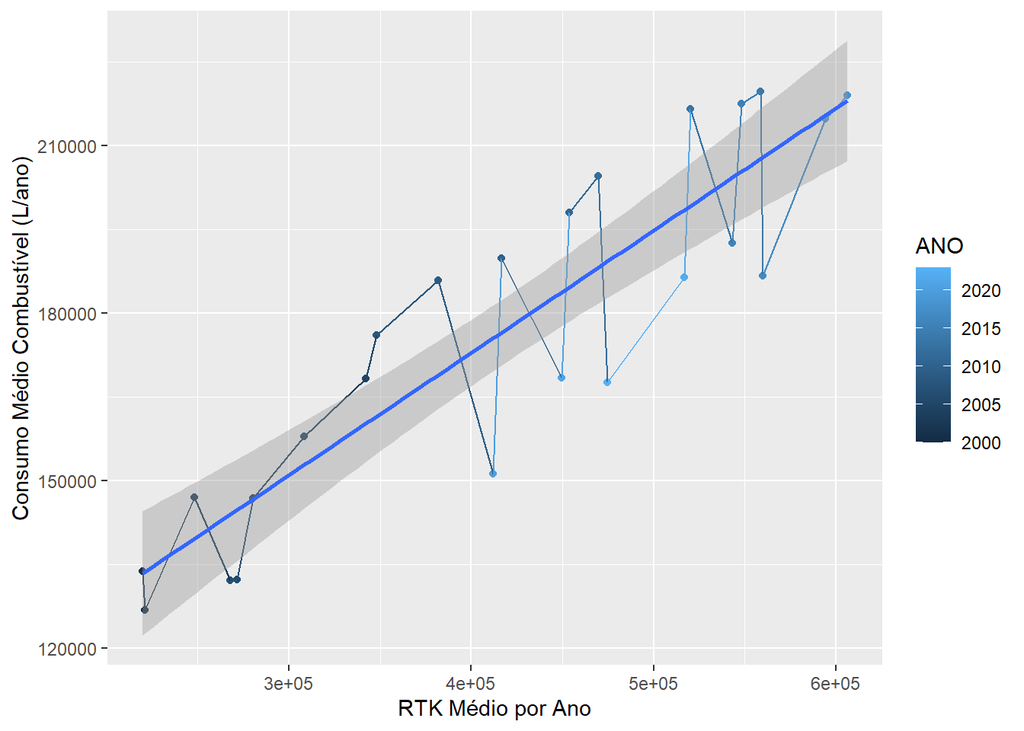

```r
subSet_Q9 <- dados3 %>%
  filter(RTK > 0, COMBUSTIVEL_LITROS > 0) %>%
  select(ANO, RTK, COMBUSTIVEL_LITROS) %>%
  group_by(ANO) %>%
  summarise (RTK_MediaAno = mean(RTK), ConsumoCombustivelMediAno = mean(COMBUSTIVEL_LITROS))

ggplot(data = subSet_Q9,
       mapping = aes(x = RTK_MediaAno,
                     y = ConsumoCombustivelMediAno,
                     color = ANO)) +
       labs(x = "RTK Médio por Ano",
            y = "Consumo Médio Combustível (L/ano)") +
       geom_point() +
       geom_line() +
       geom_smooth(method = "lm")
```

### Questão 10)

O indicador ATK (Available tonne kilometer) refere-se ao volume de tonelada quilômetro oferecida pela companhia. Crie uma visualização para explorar a relação entre estes indicadores. Considere aspectos como GRUPO_DE_VOO e NATUREZA além do anos.

```r
# Criando subset de trabalho
subSet_Q10 <- dados3


# Ajustando valores NA
subSet_Q10New <- subSet_Q10 %>% replace_na(list(PASSAGEIROS_PAGOS = 0,PASSAGEIROS_GRATIS = 0,
                                                CARGA_PAGA_KG = 0, CARGA_GRATIS_KG = 0,
                                                CORREIO_KG = 0,ASK = 0, RPK = 0, ATK = 0,
                                                RTK =0,COMBUSTIVEL_LITROS = 0,
                                                DISTANCIA_VOADA_KM = 0, DECOLAGENS = 0,
                                                CARGA_PAGA_KM = 0,CARGA_GRATIS_KM = 0,
                                                CORREIO_KM = 0, ASSENTOS = 0, PAYLOAD = 0,
                                                HORAS_VOADAS = 0,BAGAGEM_KG = 0))

# Ajustando valores em Grupo de Vôo
subSet_Q10New <- subSet_Q10New %>%
                  mutate(GRUPO_DE_VOO = case_when(
                    GRUPO_DE_VOO == "N\xc3O REGULAR" ~ "NÃO REGULAR",
                    GRUPO_DE_VOO == "N\xc3O IDENTIFICADO" ~ "NÃO IDENTIFICADO",
                    TRUE ~ GRUPO_DE_VOO
                  ))

# Ajustando valores em Natureza
subSet_Q10New <- subSet_Q10New %>%
  mutate(NATUREZA = case_when(
    NATUREZA == "DOM\xc9STICA" ~ "DOMÉSTICA",
    TRUE ~ NATUREZA
  ))

# Criando grupos
subSet_Q10New_fix <- subSet_Q10New %>%
                      select(ANO, ATK, GRUPO_DE_VOO, NATUREZA) %>%
                      filter(GRUPO_DE_VOO != "", NATUREZA != "") %>%
                      group_by(ANO, GRUPO_DE_VOO, NATUREZA) %>%
                      summarise(ATKMedio_Grupo = mean(ATK))
```

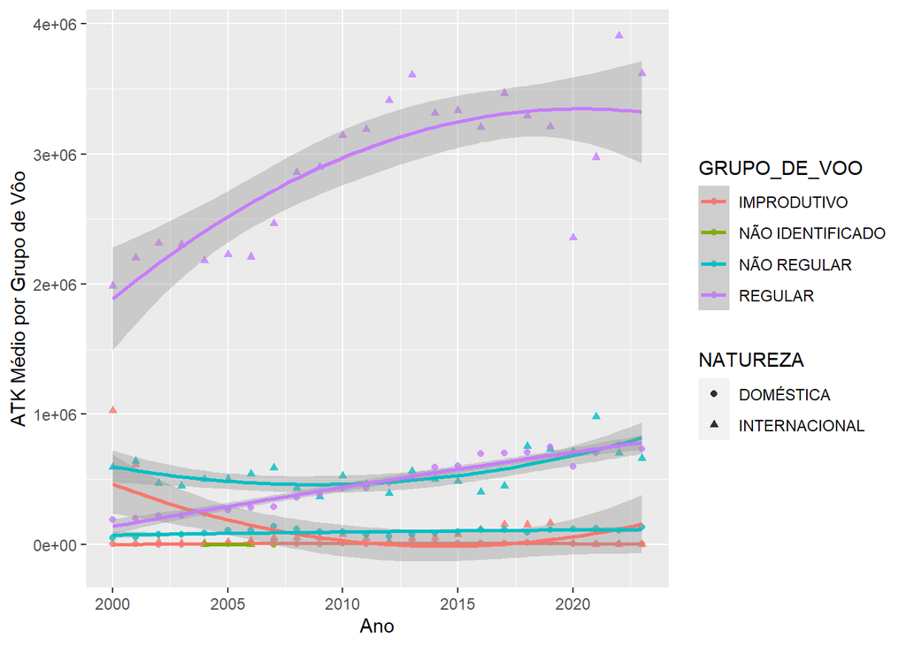

```r
# Criando gráfico
ggplot(data = subSet_Q10New_fix,
       mapping = aes(x = ANO,
                     y = ATKMedio_Grupo,
                     color = GRUPO_DE_VOO,
                     shape = NATUREZA)) +
       labs(x = "Ano",
            y = "ATK Médio por Grupo de Vôo") +
  geom_point(alpha = 0.8) +
  geom_smooth(method = "loess", span = 100)
```